# exercises

## Section 9.2 exercises

1. Create a scatterplot of `hwy` vs. `displ` where the points are pink filled in triangles.  
   A:

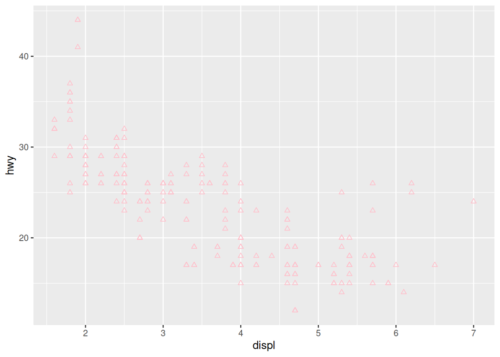

   ```r
   mpg |>
     ggplot(aes(x = displ, y = hwy)) +
     geom_point(color = "pink", shape = 2)
   ```

2. Why did the following code not result in a plot with blue points?

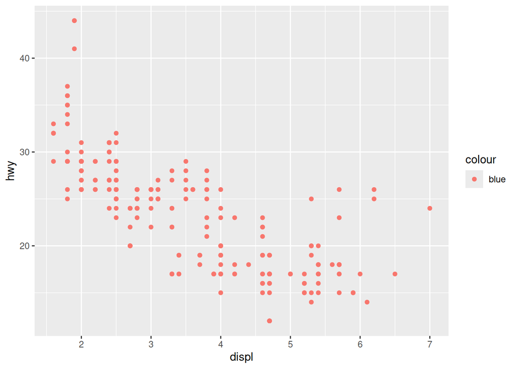

   ```r
   ggplot(mpg) +
     geom_point(aes(x = displ, y = hwy, color = "blue"))
   ```

   A: `ggplot()` interprets the `"blue"` as data instead of a color, hence it maps the categorical value `"blue"` to a color from the default palette (in this case red). The correct way to make points blue is the following.

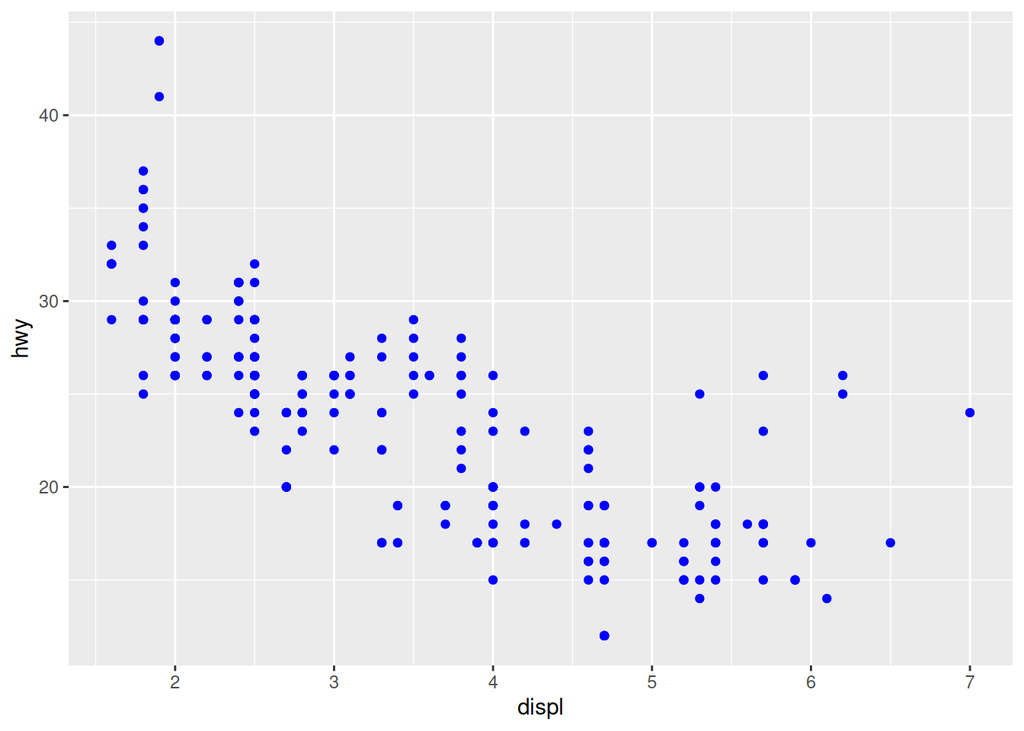

   ```r
   ggplot(mpg) +
     geom_point(aes(x = displ, y = hwy), color = "blue")
   ```

3. What does the `stroke` aesthetic do? What shapes does it work with? (Hint: use `?geom_point`)  
   A: It controls the width of the outline of filled shapes (21-25).
4. What happens if you map an aesthetic to something other than a variable name, like `aes(color = displ < 5)`? Note, you’ll also need to specify x and y.  
   A: Since `displ < 5` is a boolean expression, `ggplot()` recognizes it as a categorical variable with values determined by its evaluation.

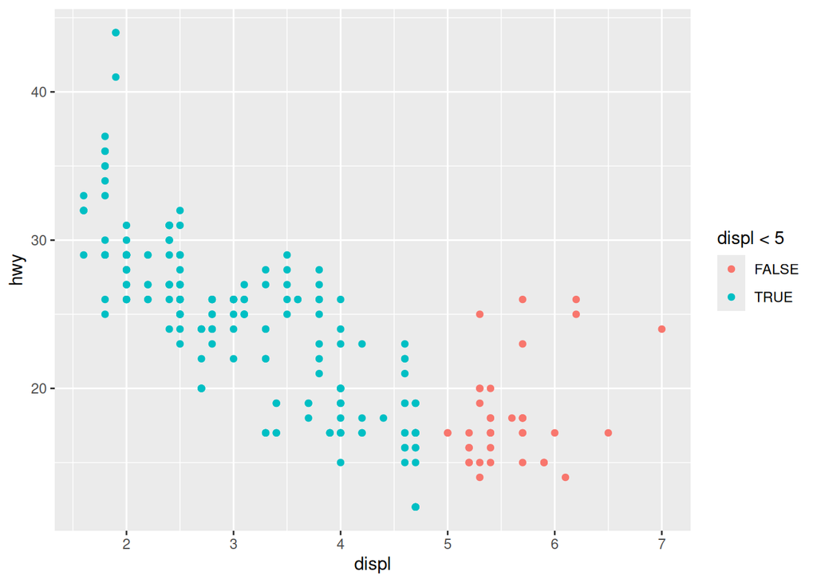

   ```r
   ggplot(mpg) +
     geom_point(aes(x = displ, y = hwy, color = displ < 5))
   ```

## Section 9.3 exercises

1. What geom would you use to draw a line chart? A boxplot? A histogram? An area chart?  
   A: `geom_line()`, `geom_boxplot()`, `geom_histogram()` and `geom_area()`.
2. Earlier in this chapter we used `show.legend` without explaining it:

   ```r
   ggplot(mpg, aes(x = displ, y = hwy)) +
     geom_smooth(aes(color = drv), show.legend = FALSE)
   ```

   What does `show.legend = FALSE` do here? What happens if you remove it? Why do you think we used it earlier?  
   A: It hides the legend of the plot.
3. What does the `se` argument to `geom_smooth()` do?  
   A: It displays a shaded confidence region around the line.
4. Recreate the R code necessary to generate the following graphs. Note that wherever a categorical variable is used in the plot, it’s `drv`.

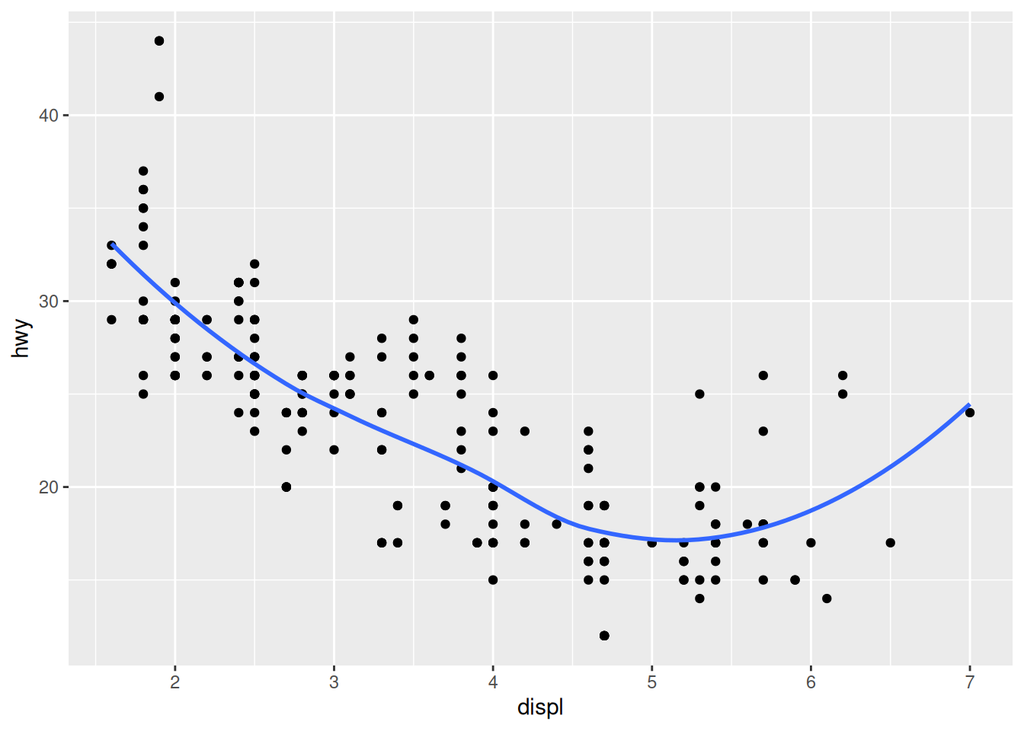

   ```r
   ggplot(mpg, aes(x = displ, y = hwy)) +
     geom_point() +
     geom_smooth(se = FALSE)
   ```

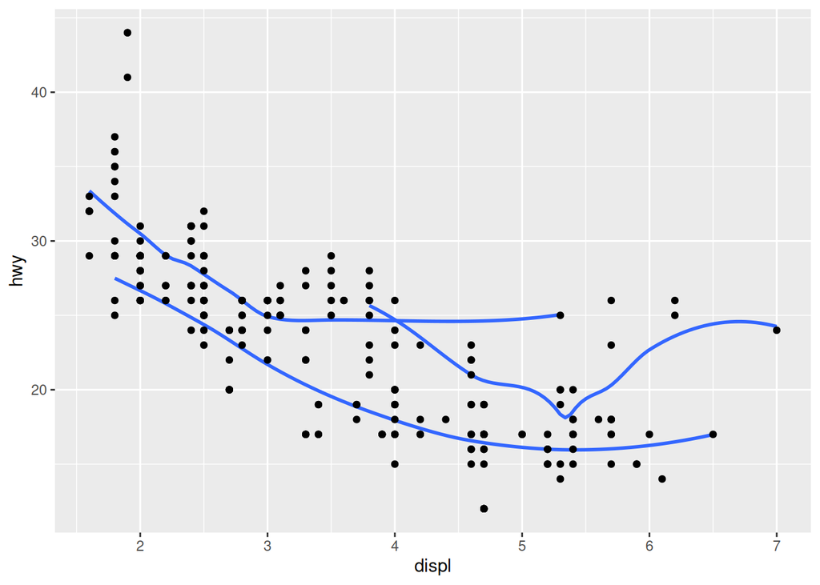

   ```r
   ggplot(mpg, aes(x = displ, y = hwy)) +
     geom_smooth(aes(group = drv), se = FALSE) +
     geom_point()
   ```

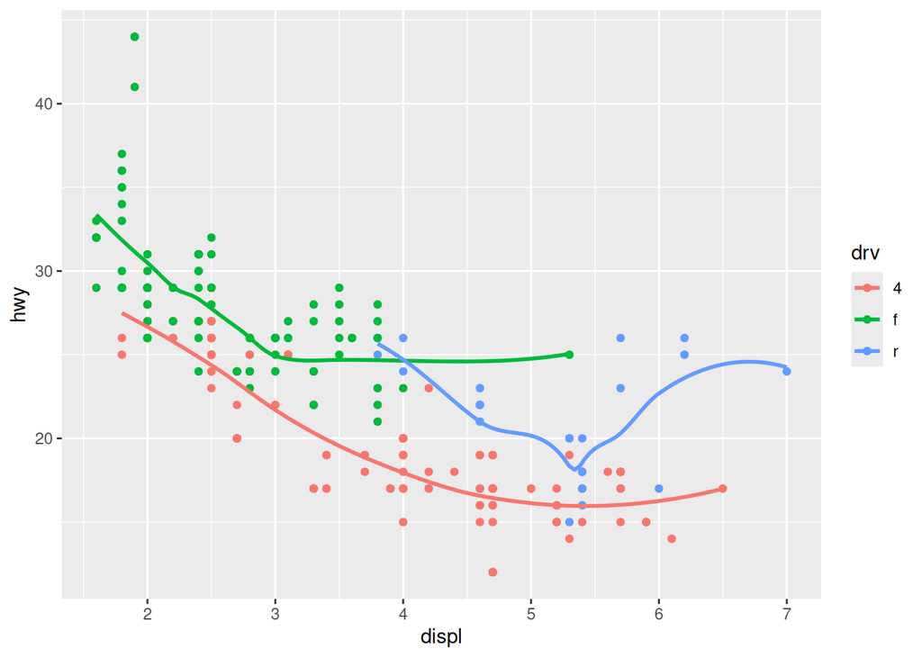

   ```r
   ggplot(mpg, aes(x = displ, y = hwy, color = drv)) +
     geom_point() +
     geom_smooth(se = FALSE)
   ```

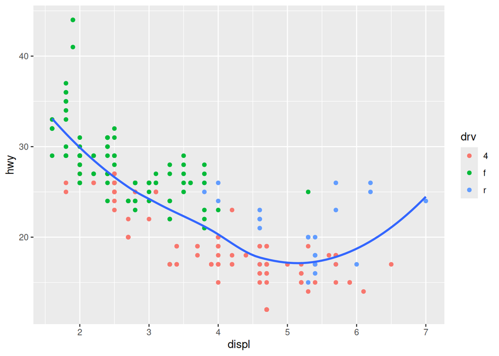

   ```r
   ggplot(mpg, aes(x = displ, y = hwy)) +
     geom_point(aes(color = drv)) +
     geom_smooth(se = FALSE)
   ```

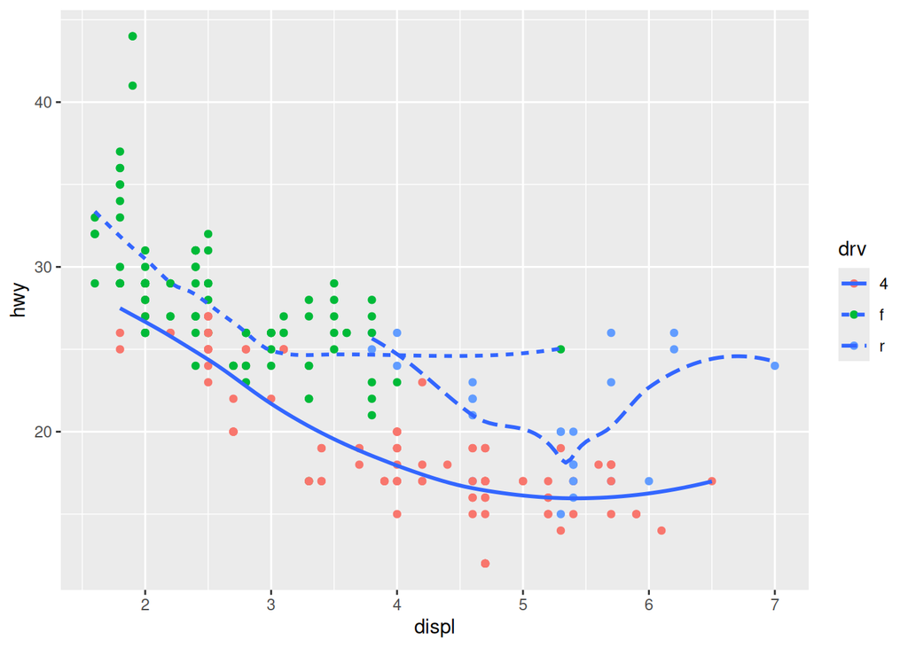

   ```r
   ggplot(mpg, aes(x = displ, y = hwy)) +
     geom_point(aes(color = drv)) +
     geom_smooth(aes(linetype = drv), se = FALSE)
   ```

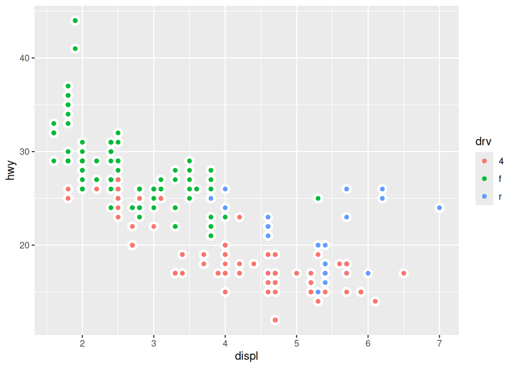

   ```r
   ggplot(mpg, aes(x = displ, y = hwy)) +
     geom_point(size = 4, color = "white") +
     geom_point(aes(color = drv))
   ```

## Section 9.4 exercises

1. What happens if you facet on a continuous variable?  
   A: `ggplot()` treats it as a categorical variable (separate facet for each value).

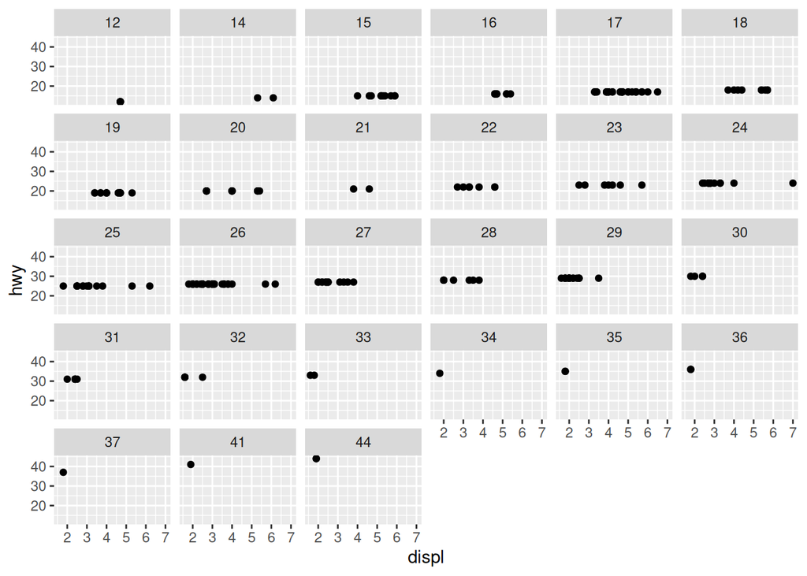

   ```r
   ggplot(mpg, aes(x = displ, y = hwy)) +
     geom_point() +
     facet_wrap(~hwy)
   ```

2. What do the empty cells in the plot above with `facet_grid(drv ~ cyl)` mean? Run the following code. How do they relate to the resulting plot?  
   A: Empty grids indicate that no observation of this particular combination of values exist.

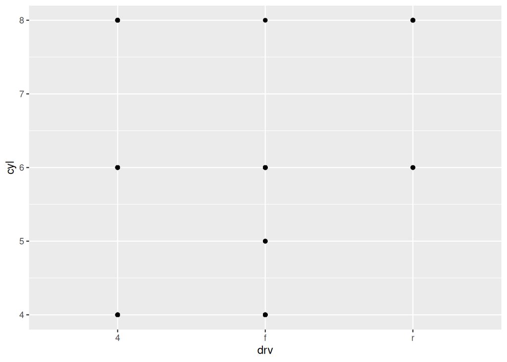

   ```r
   ggplot(mpg) +
     geom_point(aes(x = drv, y = cyl))
   ```

3. What plots does the following code make? What does `.` do?  
   A: a dummy variable if one only wants to facet along one variable.

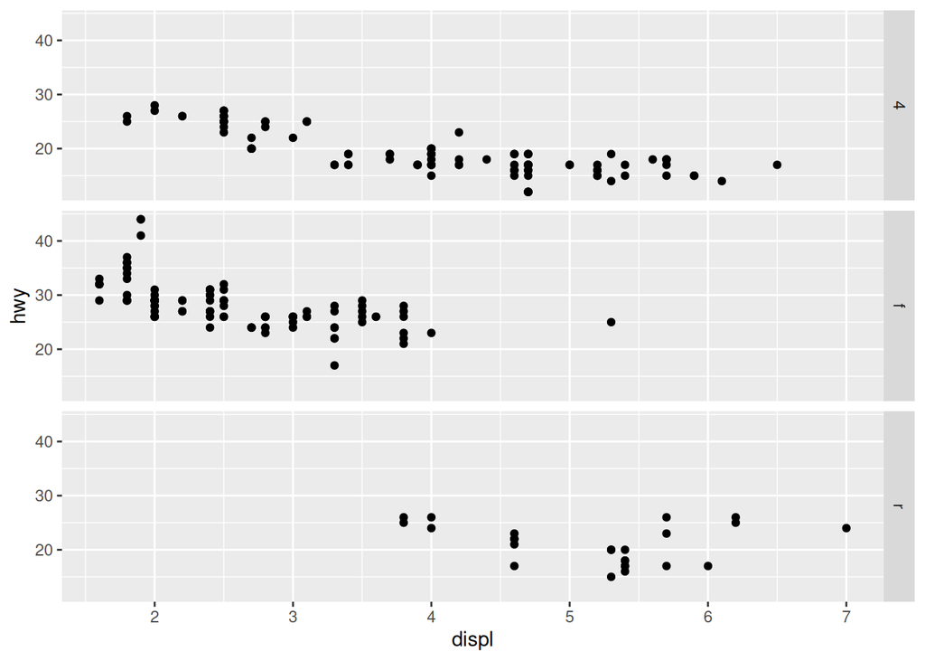

   ```r
   ggplot(mpg) +
     geom_point(aes(x = displ, y = hwy)) +
     facet_grid(drv ~ .)
   ```

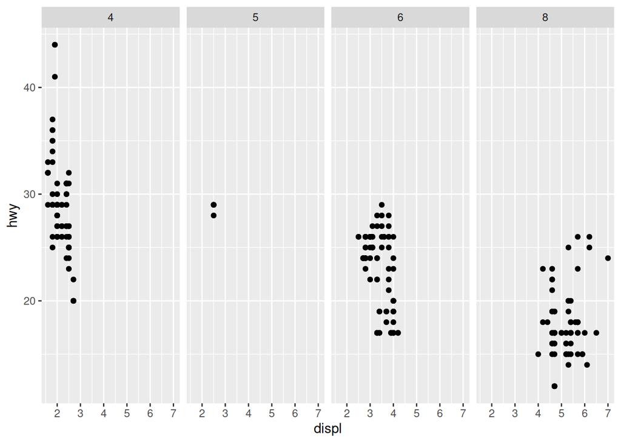

   ```r
   ggplot(mpg) +
     geom_point(aes(x = displ, y = hwy)) +
     facet_grid(. ~ cyl)
   ```

4. Take the first faceted plot in this section:

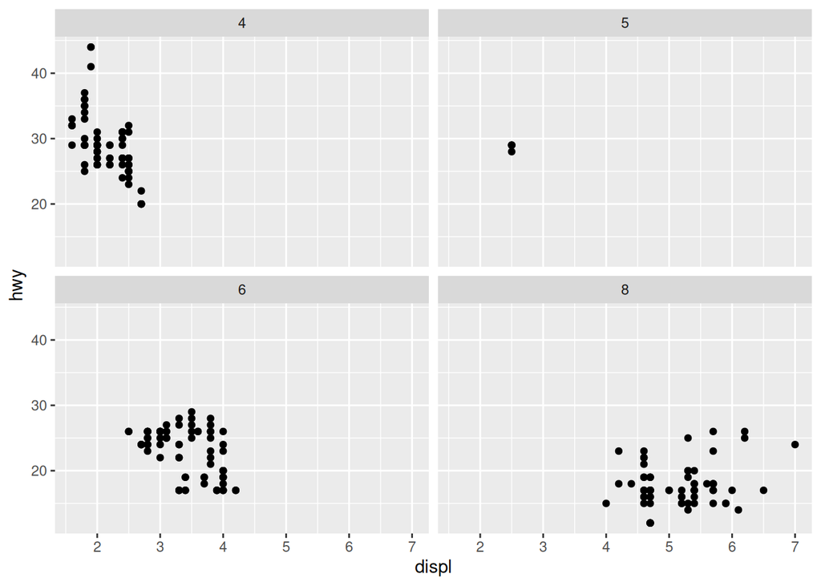

   ```r
   ggplot(mpg) +
     geom_point(aes(x = displ, y = hwy)) +
     facet_wrap(~ cyl, nrow = 2)
   ```

   What are the advantages to using faceting instead of the color aesthetic? What are the disadvantages? How might the balance change if you had a larger dataset?  
   A: faceting makes it easier to isolate out data within each facet, but makes it harder to compare across different facets.
5. Read `?facet_wrap`. What does `nrow` do? What does `ncol` do? What other options control the layout of the individual panels? Why doesn’t `facet_grid()` have `nrow` and `ncol` arguments?  
   A: the number of rows and columns of `facet_grid()` in determined by the number of categorical variables assigned.
6. Which of the following plots makes it easier to compare engine size (`displ`) across cars with different drive trains? What does this say about when to place a faceting variable across rows or columns?  
   A: histograms naturally works better with faceting across rows.

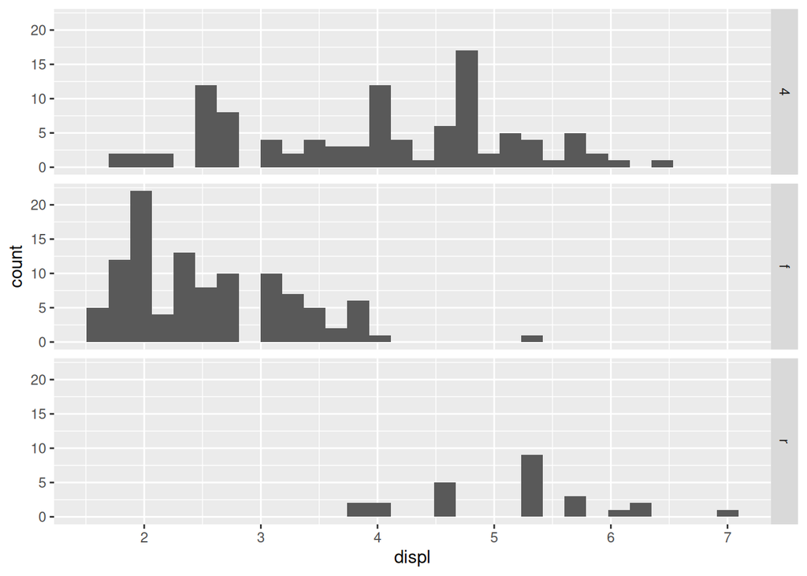

   ```r
   ggplot(mpg, aes(x = displ)) +
     geom_histogram() +
     facet_grid(drv ~ .)
   ```

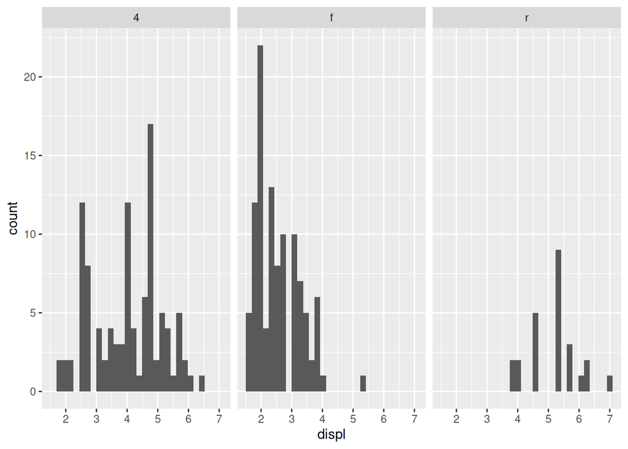

   ```r
   ggplot(mpg, aes(x = displ)) +
     geom_histogram() +
     facet_grid(. ~ drv)
   ```

7. Recreate the following plot using `facet_wrap()` instead of `facet_grid()`. How do the positions of the facet labels change?

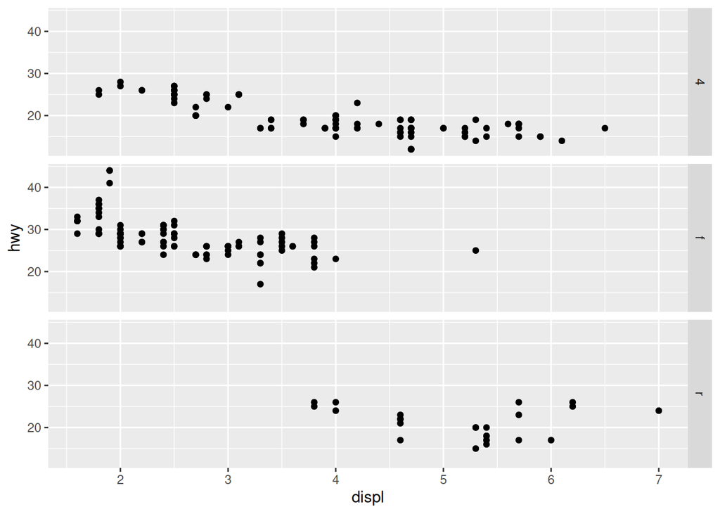

   ```r
   ggplot(mpg) +
     geom_point(aes(x = displ, y = hwy)) +
     facet_grid(drv ~ .)
   ```

   A: The facet labels move to the top side.

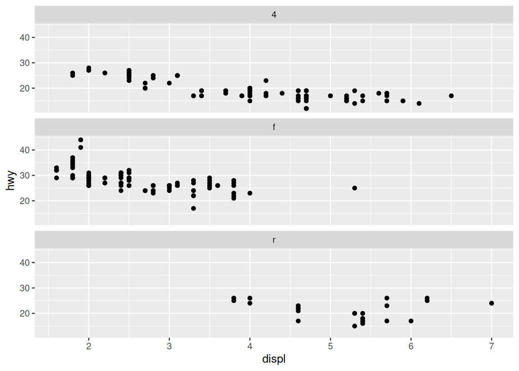

   ```r
   ggplot(mpg) +
     geom_point(aes(x = displ, y = hwy)) +
     facet_wrap(~drv, ncol = 1)
   ```

## Section 9.5 exercises

1. What is the default geom associated with `stat_summary()`? How could you rewrite the previous plot to use that geom function instead of the stat function?  
   A: the default geom is `geom_pointrange()`.

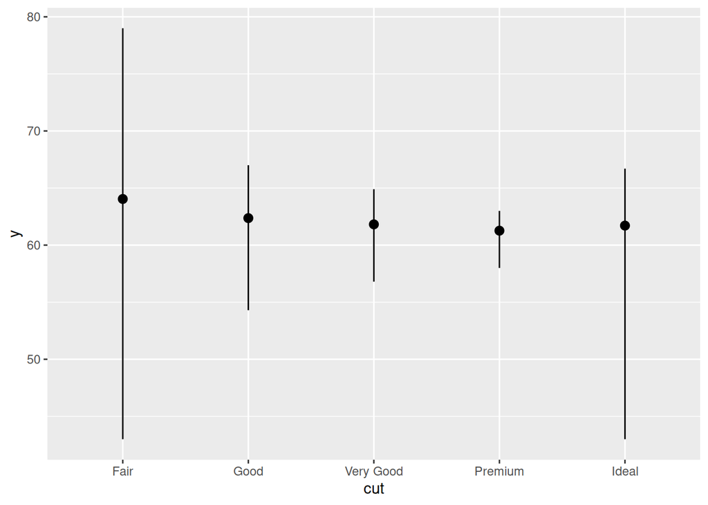

   ```r
   diamonds |>
     group_by(cut) |>
     summarise(
       y = mean(depth),
       ymin = min(depth),
       ymax = max(depth)
     ) |>
     ggplot(aes(x = cut, y = y, ymin = ymin, ymax = ymax)) +
     geom_pointrange()
   ```

2. What does `geom_col()` do? How is it different from `geom_bar()`?  
   A: the heights of the bars in `geom_col()` represents the values in the data, and it uses `stat_identity` by default.
3. Most geoms and stats come in pairs that are almost always used in concert. Make a list of all the pairs. What do they have in common? (Hint: Read through the documentation.)
4. What variables does `stat_smooth()` compute? What arguments control its behavior?  
   A: `stat_smooth()` computes the following variables:
   - `after_stat(y)` or `after_stat(x)`: Predicted value.
   - `after_stat(ymin) or`after_stat(xmin)`: Lower pointwise confidence band around the mean.
   - `after_stat(ymax)` or `after_stat(xmax)`: Upper pointwise confidence band around the mean.
   - `after_stat(se)`: Standard error.
5. In our proportion bar chart, we needed to set `group = 1`. Why? In other words, what is the problem with these two graphs?  
   A: Without explicit declaration, `ggplot()` assumes that `group = cut`. Under this logic, the stat `prop` is computed within each cut, hence every bar has height 1. Setting `group = 1` is just a way to group the entire dataset together.

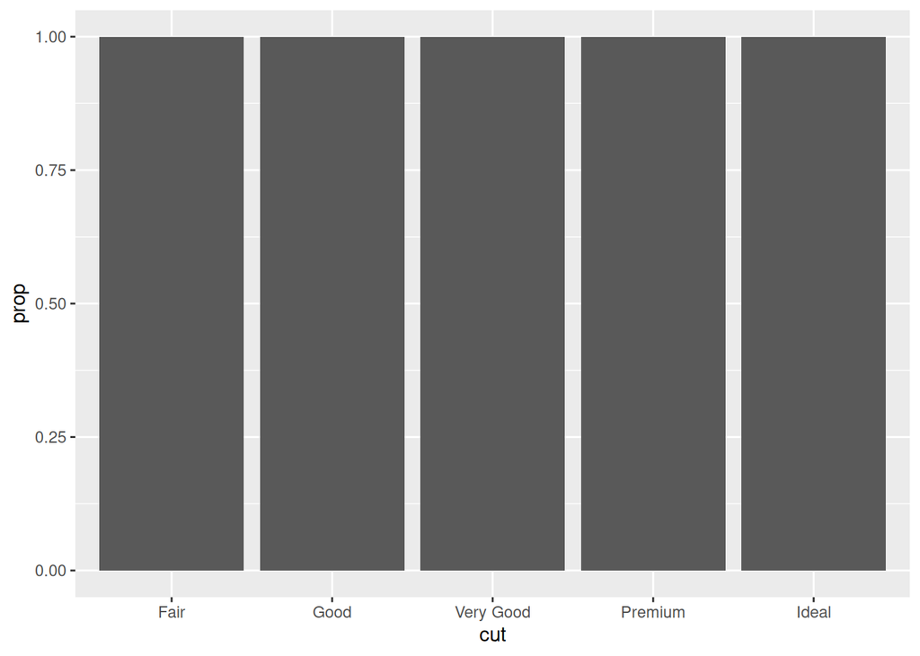

   ```r
   ggplot(diamonds, aes(x = cut, y = after_stat(prop))) +
     geom_bar()
   ```

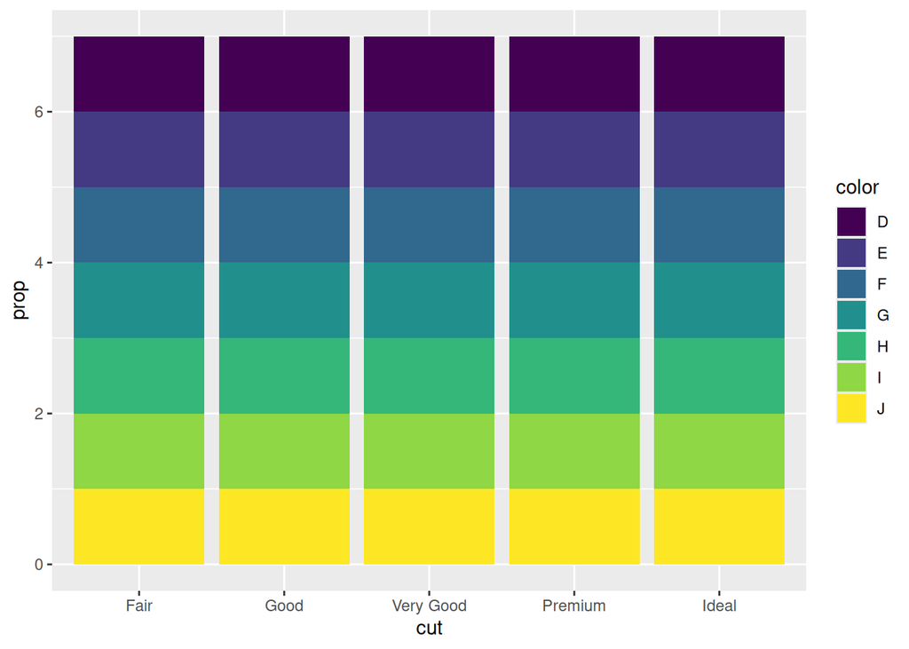

   ```r
   ggplot(diamonds, aes(x = cut, fill = color, y = after_stat(prop))) +
     geom_bar()
   ```

## Section 9.6 exercises

1. What is the problem with the following plot? How could you improve it?

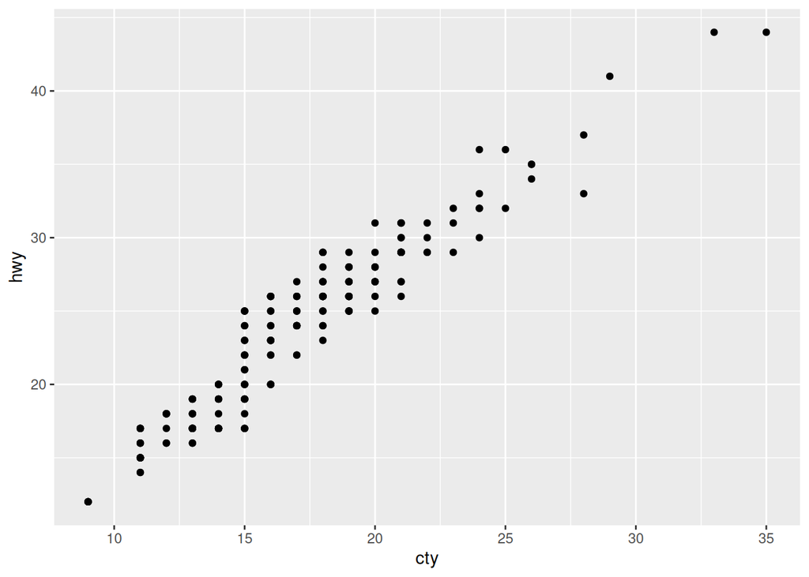

   ```r
   ggplot(mpg, aes(x = cty, y = hwy)) +
     geom_point()
   ```

   A: The underlying data are rounded to intergers, hence multiple points overlap each other. Applying some randomness using `geom_jitter()` helps with the overall plotting.

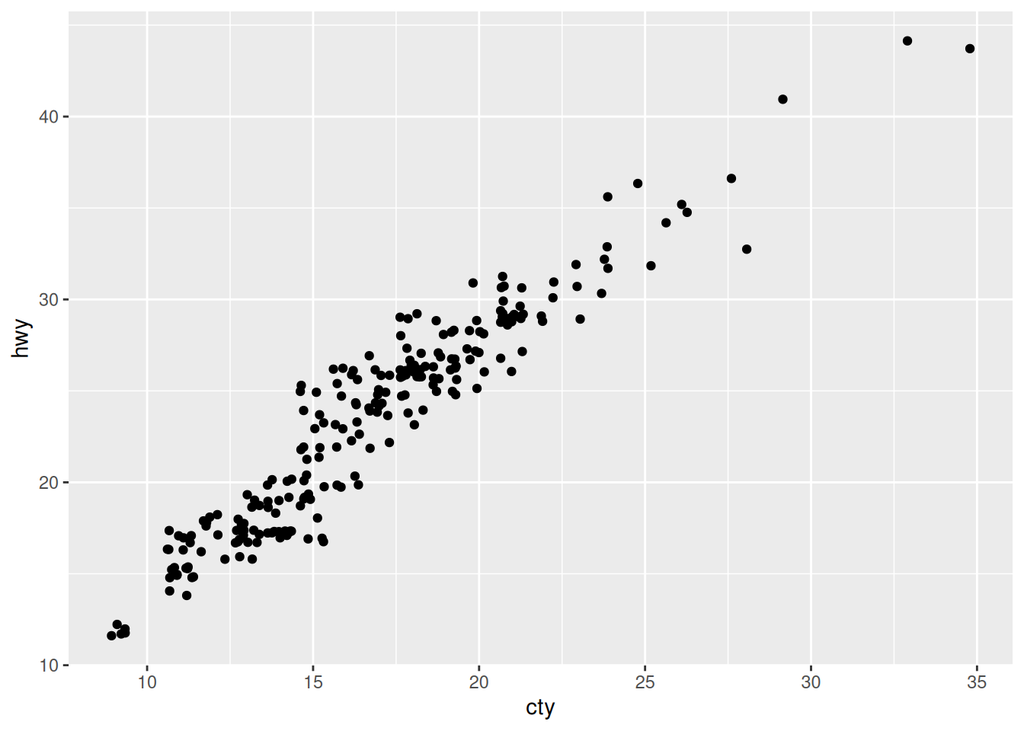

   ```r
   ggplot(mpg, aes(x = cty, y = hwy)) +
     geom_jitter()
   ```

2. What, if anything, is the difference between the two plots? Why?

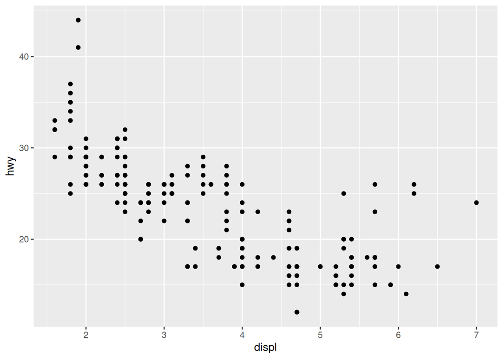

   ```r
   ggplot(mpg, aes(x = displ, y = hwy)) +
     geom_point()
   ```

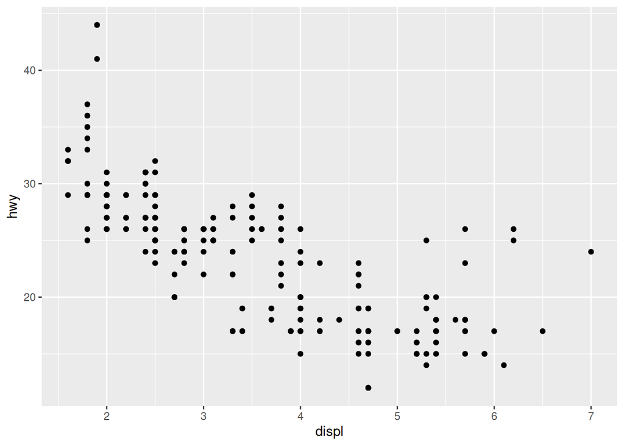

   ```r
   ggplot(mpg, aes(x = displ, y = hwy)) +
     geom_point(position = "identity")
   ```

   A: The plots are identical since the default value for the argument `position` in `geom_point()` is `"identity"`.
3. What parameters to `geom_jitter()` control the amount of jittering?  
   A: `width` and `height` control the amount of horizontal and vertical jitter, respectively.
4. Compare and contrast `geom_jitter()` with `geom_count()`.  
   A: `geom_jitter()` solves overplotting by adding randomness, while `geom_count()` solves this by adjusting point sizes.

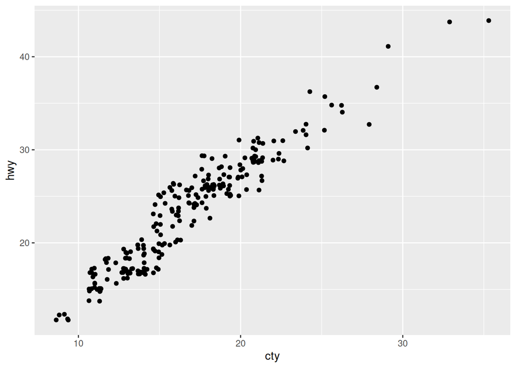

   ```r
   ggplot(mpg, aes(x = cty, y = hwy)) +
     geom_jitter()
   ```

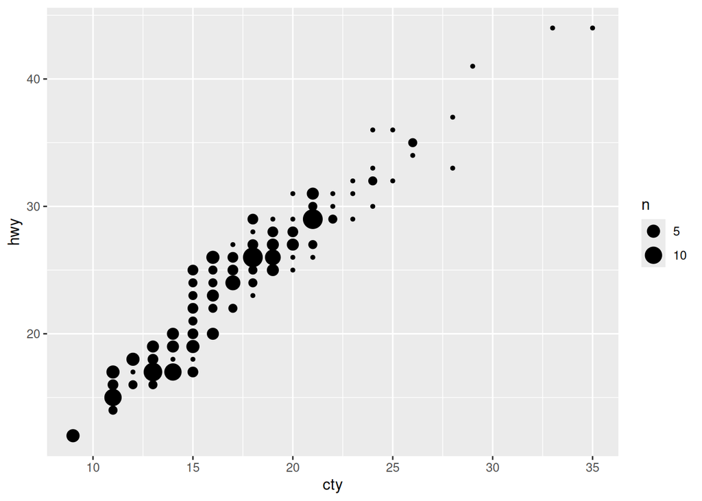

   ```r
   ggplot(mpg, aes(x = cty, y = hwy)) +
     geom_count()
   ```

5. What’s the default position adjustment for `geom_boxplot()`? Create a visualization of the `mpg` dataset that demonstrates it.  
   A: The default position adjustment is `dodge2`.

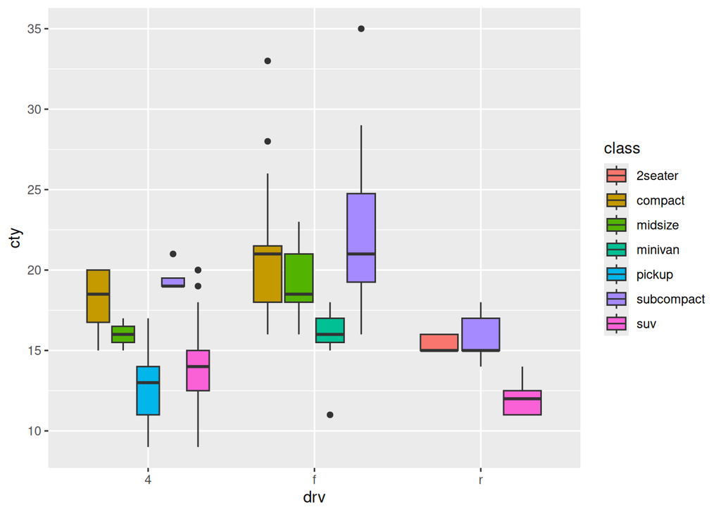

   ```r
   ggplot(mpg, aes(x = drv, y = cty, fill = class)) +
     geom_boxplot()
   ```

## Section 9.7 exercises

1. Turn a stacked bar chart into a pie chart using `coord_polar()`.  
   A:

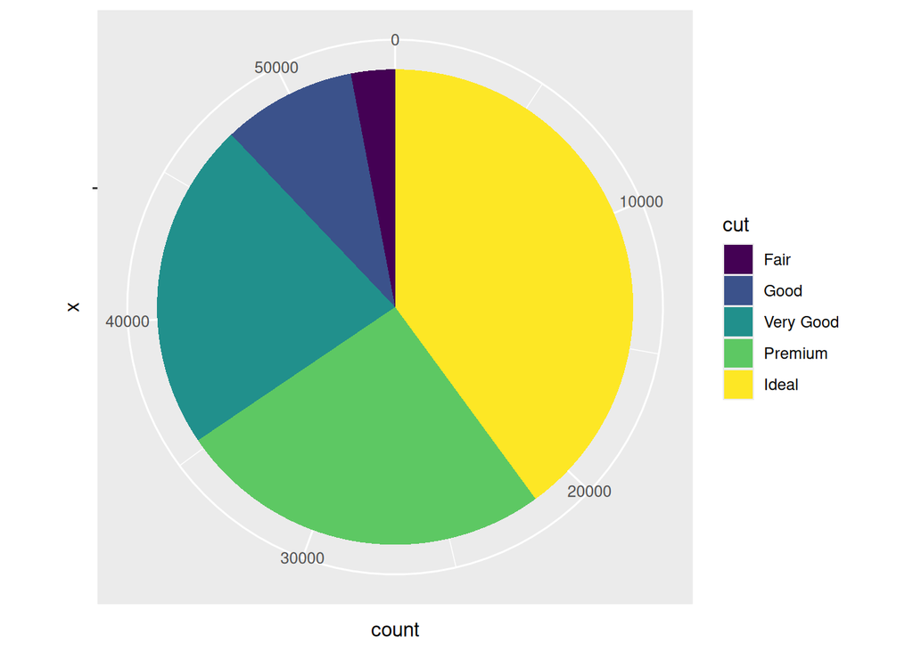

   ```r
   ggplot(diamonds, aes(x = "", fill = cut)) +
     geom_bar(width = 1) +
     coord_polar(theta = "y")
   ```

2. What’s the difference between `coord_quickmap()` and `coord_map()`?  
   A: `coord_map()` uses true map projection and transforms each point mathematically. `coord_quickmap()` assumes a small rectangular region and only rescale among the axes.
3. What does the following plot tell you about the relationship between city and highway mpg? Why is `coord_fixed()` important? What does `geom_abline()` do?

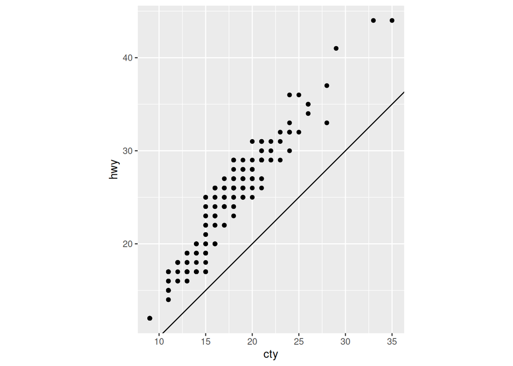

   ```r
   ggplot(data = mpg, mapping = aes(x = cty, y = hwy)) +
     geom_point() +
     geom_abline() +
     coord_fixed()
   ```

   A: `coord_fixed()` maintains a specific ratio between the axes. `geom_abline` adds a reference diagonal marking the line where `x = y`. The plot demonstrates that `hwy` is always larger than `cty`.